# Лабораторная 4. Регрессионные модели

## 1. Спрос и температура, январь 2014

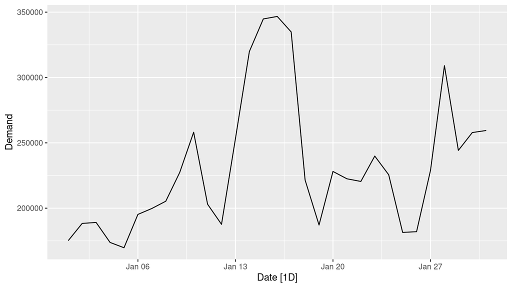

```r
jan14 <- vic_elec |>
  filter(Date >= as.Date("2014-01-01"), Date <= as.Date("2014-01-31")) |>
  index_by(Date) |>
  summarise(Demand = sum(Demand), Temperature = max(Temperature))
autoplot(jan14, Demand)
```

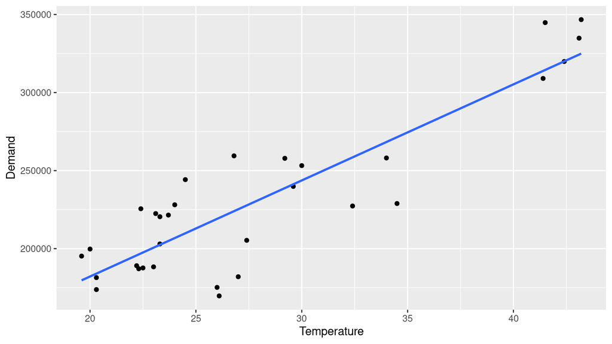

```r
jan14 |>
  ggplot(aes(Temperature, Demand)) +
  geom_point() +
  geom_smooth(method = "lm", se = FALSE)
```

В январе более жаркие дни дают больший спрос на кондиционирование, поэтому наклон положительный. Это только летний кусок, не вся кривая «холод и жара».

```r
fit_jan <- jan14 |> model(TSLM(Demand ~ Temperature))
report(fit_jan)
```

```
## Series: Demand
## Model: TSLM
##
## Residuals:
##      Min       1Q   Median       3Q      Max
## -49978.2 -10218.9   -121.3  18533.2  35440.6
##
## Coefficients:
##             Estimate Std. Error t value Pr(>|t|)
## (Intercept)  59083.9    17424.8   3.391  0.00203 **
## Temperature   6154.3      601.3  10.235 3.89e-11 ***
## ---
## Signif. codes:  0 '***' 0.001 '**' 0.01 '*' 0.05 '.' 0.1 ' ' 1
##
## Residual standard error: 24540 on 29 degrees of freedom
## Multiple R-squared: 0.7832,  Adjusted R-squared: 0.7757
## F-statistic: 104.7 on 1 and 29 DF, p-value: 3.8897e-11
```

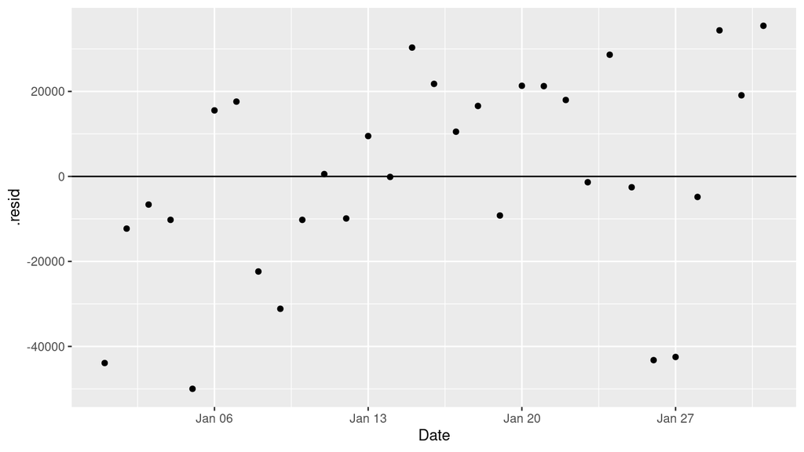

```r
augment(fit_jan) |>
  ggplot(aes(Date, .resid)) +
  geom_point() +
  geom_hline(yintercept = 0)
```

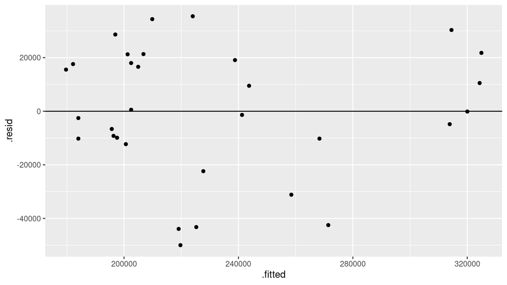

```r
augment(fit_jan) |>
  ggplot(aes(.fitted, .resid)) +
  geom_point() +
  geom_hline(yintercept = 0)
```

Остатки не выглядят как ровный шум: есть дни, далеко от линии. Линейной связи на 31 точке мало, модель грубая.

```r
scenarios <- new_data(jan14, 2) |>
  mutate(Temperature = c(15, 35))
fc_jan <- forecast(fit_jan, new_data = scenarios)
fc_jan
```

```
## # A fable: 2 x 5 [1D]
## # Key:     .model [1]
##   .model                     Date
##   <chr>                      <date>
## 1 TSLM(Demand ~ Temperature) 2014-02-01
## 2 TSLM(Demand ~ Temperature) 2014-02-02
## # ℹ 3 more variables: Demand <dist>, .mean <dbl>, Temperature <dbl>
```

```r
fc_jan |> hilo(level = 95)
```

```
## # A tsibble: 2 x 6 [1D]
## # Key:       .model [1]
##   .model                     Date
##   <chr>                      <date>
## 1 TSLM(Demand ~ Temperature) 2014-02-01
## 2 TSLM(Demand ~ Temperature) 2014-02-02
## # ℹ 4 more variables: Demand <dist>, .mean <dbl>, Temperature <dbl>,
## #   `95%` <hilo>
```

При 35°C точечный прогноз выше, чем при 15°C, интервалы широкие. Верить им как плану на день не стоит: 15°C для января в Victoria — холодный день, и зависимость вне облака январских точек может быть другой. На всей истории спрос высокий и в холод, и в жару.

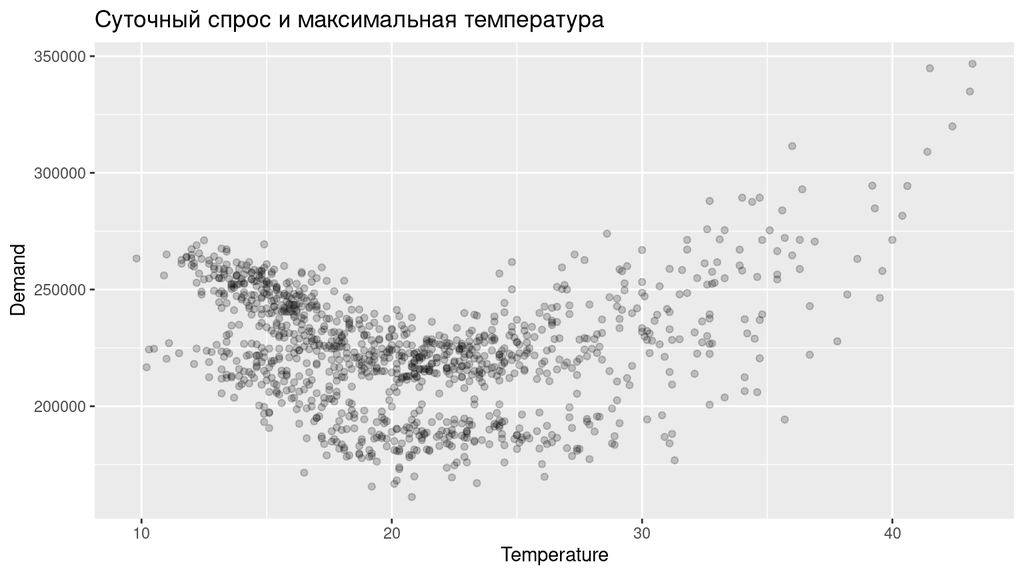

```r
vic_daily <- vic_elec |>
  index_by(Date) |>
  summarise(Demand = sum(Demand), Temperature = max(Temperature))
vic_daily |>
  ggplot(aes(Temperature, Demand)) +
  geom_point(alpha = 0.2) +
  labs(title = "Суточный спрос и максимальная температура")
```

Облако U-образное. Прямая, оцененная по жаркому январю, не описывает зимние дни.

## 2. Олимпийский бег

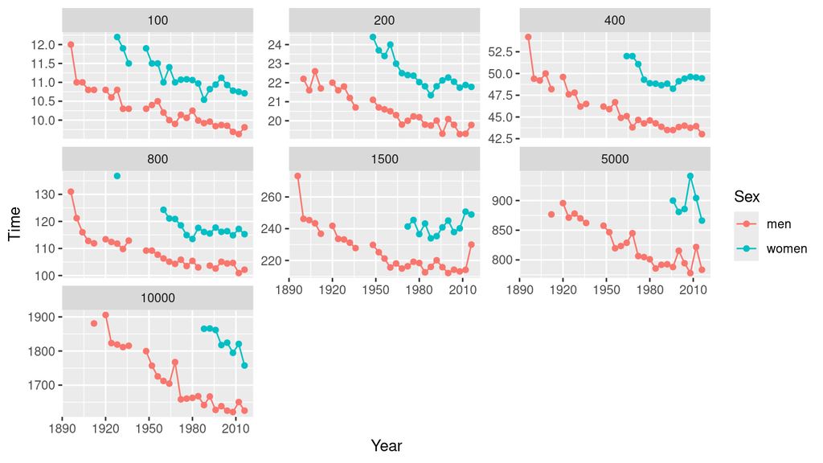

```r
olympic_running |>
  ggplot(aes(Year, Time, colour = Sex)) +
  geom_line() +
  geom_point() +
  facet_wrap(~ Length, scales = "free_y")
```

Победное время снижается. У коротких дистанций падение выходит на полку, у длинных спад продолжается дольше. Мужчины и женщины идут параллельно, у женщин ряд короче.

```r
fit_oly <- olympic_running |>
  model(TSLM(Time ~ trend()))
tidy(fit_oly) |> filter(term == "trend")
```

[output not shown]

```
## # A tibble: 0 × 8
## # ℹ 8 variables: Length <int>, Sex <chr>, .model <chr>, term <chr>,
## #   estimate <dbl>, std.error <dbl>, statistic <dbl>, p.value <dbl>
```

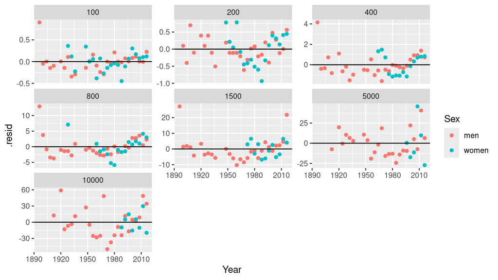

```r
augment(fit_oly) |>
  ggplot(aes(Year, .resid, colour = Sex)) +
  geom_point() +
  facet_wrap(~ Length, scales = "free_y") +
  geom_hline(yintercept = 0)
```

Остатки систематически положительны в начале и в конце и отрицательны в середине: улучшение замедляется. Прямая завышает будущий спад.

```r
fc_oly <- forecast(fit_oly, h = 1)
fc_oly |> hilo(level = 95)
```

```
## # A tsibble: 14 x 7 [4Y]
## # Key:       Length, Sex, .model [14]
##    Length Sex   .model                Year
##     <int> <chr> <chr>                <dbl>
##  1    100 men   TSLM(Time ~ trend())  2020
##  2    100 women TSLM(Time ~ trend())  2020
##  3    200 men   TSLM(Time ~ trend())  2020
##  4    200 women TSLM(Time ~ trend())  2020
##  5    400 men   TSLM(Time ~ trend())  2020
##  6    400 women TSLM(Time ~ trend())  2020
##  7    800 men   TSLM(Time ~ trend())  2020
##  8    800 women TSLM(Time ~ trend())  2020
##  9   1500 men   TSLM(Time ~ trend())  2020
## 10   1500 women TSLM(Time ~ trend())  2020
## 11   5000 men   TSLM(Time ~ trend())  2020
## 12   5000 women TSLM(Time ~ trend())  2020
## 13  10000 men   TSLM(Time ~ trend())  2020
## 14  10000 women TSLM(Time ~ trend())  2020
## # ℹ 3 more variables: Time <dist>, .mean <dbl>, `95%` <hilo>
```

Прогноз на следующие Игры (2020, если ряд кончается 2016) — продолжение прямой. Допущения: линейный тренд сохранится, ошибки независимы и одной дисперсии, ключи Length и Sex не влияют друг на друга. По остаткам линейность уже сомнительна, поэтому интервал рисует точность, которой у прямой нет.

## 3. Эластичность в лог-лог модели

Модель $\log y = \beta_0 + \beta_1 \log x + \varepsilon$.

Отсюда $y = e^{\beta_0 + \varepsilon} x^{\beta_1}$.

Производная: $dy/dx = \beta_1 e^{\beta_0 + \varepsilon} x^{\beta_1 - 1} = \beta_1 y / x$.

Эластичность $(dy/dx)\cdot(x/y) = \beta_1$. Коэффициент при логарифме предиктора и есть эластичность: на 1% роста $x$ ответ $y$ меняется примерно на $\beta_1$ процентов.

## 4. Сувениры

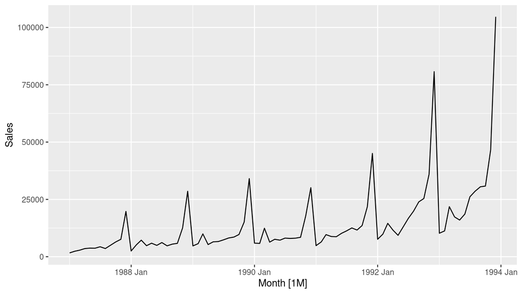

```r
autoplot(souvenirs, Sales)
```

Продажи растут, каждый год есть пик, амплитуда пиков увеличивается. Март с 1988 и декабрь выделяются. Логарифм нужен, потому что размах сезона растёт вместе с уровнем: на исходной шкале одна дисперсия ошибки не подходит.

```r
souv <- souvenirs |>
  mutate(festival = month(Month) == 3 & year(Month) >= 1988)
fit_souv <- souv |>
  model(TSLM(log(Sales) ~ trend() + season() + festival))
report(fit_souv)
```

```
## Series: Sales
## Model: TSLM
## Transformation: log(Sales)
##
## Residuals:
##       Min        1Q    Median        3Q       Max
## -0.336727 -0.127571  0.002568  0.109106  0.376714
##
## Coefficients:
##                 Estimate Std. Error t value Pr(>|t|)
## (Intercept)    7.6196670  0.0742471 102.626  < 2e-16 ***
## trend()        0.0220198  0.0008268  26.634  < 2e-16 ***
## season()year2  0.2514168  0.0956790   2.628 0.010555 *
## season()year3  0.2660828  0.1934044   1.376 0.173275
## season()year4  0.3840535  0.0957075   4.013 0.000148 ***
## season()year5  0.4094870  0.0957325   4.277 5.88e-05 ***
## season()year6  0.4488283  0.0957647   4.687 1.33e-05 ***
## season()year7  0.6104545  0.0958039   6.372 1.71e-08 ***
## season()year8  0.5879644  0.0958503   6.134 4.53e-08 ***
## season()year9  0.6693299  0.0959037   6.979 1.36e-09 ***
## season()year10 0.7473919  0.0959643   7.788 4.48e-11 ***
## season()year11 1.2067479  0.0960319  12.566  < 2e-16 ***
## season()year12 1.9622412  0.0961066  20.417  < 2e-16 ***
## festivalTRUE   0.5015151  0.1964273   2.553 0.012856 *
## ---
## Signif. codes:  0 '***' 0.001 '**' 0.01 '*' 0.05 '.' 0.1 ' ' 1
##
## Residual standard error: 0.179 on 70 degrees of freedom
## Multiple R-squared: 0.9567,  Adjusted R-squared: 0.9487
## F-statistic:   119 on 13 and 70 DF, p-value: < 2.22e-16
```

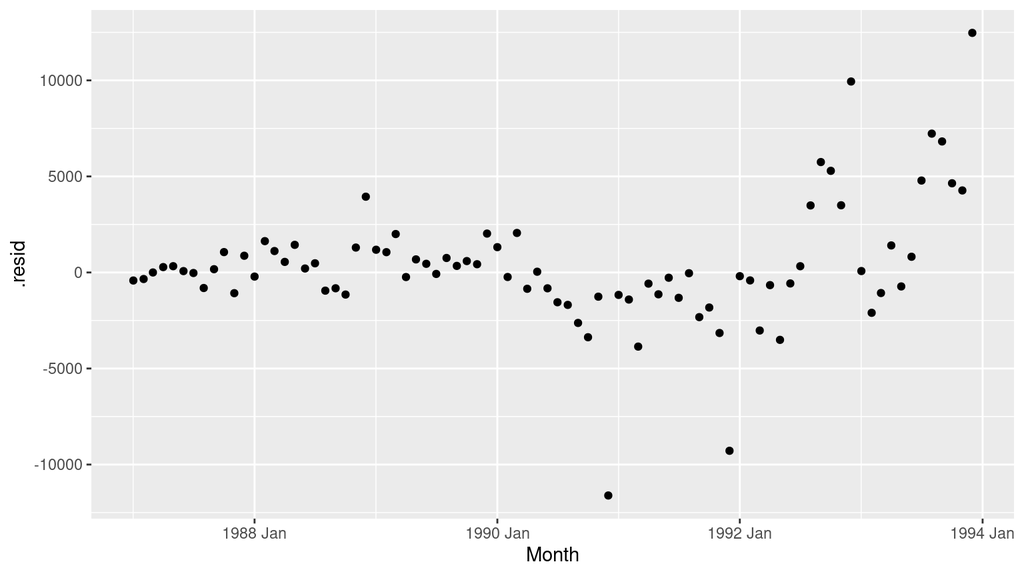

```r
augment(fit_souv) |>
  ggplot(aes(Month, .resid)) +
  geom_point()
```

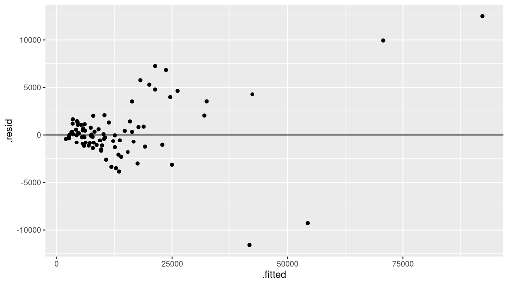

```r
augment(fit_souv) |>
  ggplot(aes(.fitted, .resid)) +
  geom_point() +
  geom_hline(yintercept = 0)
```

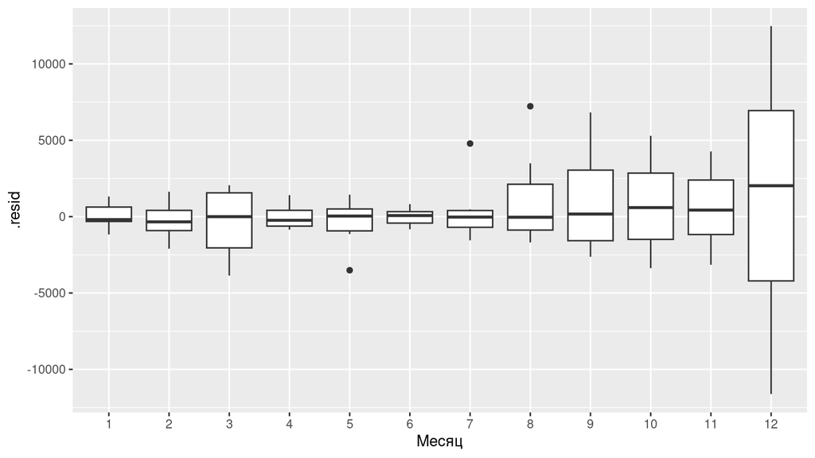

```r
augment(fit_souv) |>
  ggplot(aes(factor(month(Month)), .resid)) +
  geom_boxplot() +
  labs(x = "Месяц")
```

Коэффициент тренда — средний месячный рост логарифма продаж. Сезонные дамми показывают, насколько месяц отличается от базового. Дамми фестиваля добавляет мартовский всплеск начиная с 1988. Если остатки по месяцам всё ещё разной ширины или Ljung–Box отвергает независимость, в ряде осталась автокорреляция, и регрессия её не забрала.

```r
augment(fit_souv) |> features(.innov, ljung_box, lag = 24)
```

```
## # A tibble: 1 × 3
##   .model                                           lb_stat lb_pvalue
##   <chr>                                              <dbl>     <dbl>
## 1 TSLM(log(Sales) ~ trend() + season() + festival)    112.  2.15e-13
```

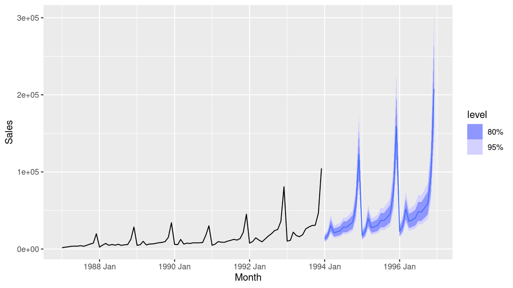

```r
future_souv <- new_data(souv, 36) |>
  mutate(festival = month(Month) == 3)
fc_souv <- forecast(fit_souv, new_data = future_souv)
autoplot(fc_souv, souvenirs)
```

Прогноз на 1994–1996 продолжает тренд и сезон. Улучшение: ARIMA-ошибки вместо белого шума, или отдельный меняющийся сезонный индекс, потому что амплитуда пиков росла быстрее, чем это ловит один логарифм.

## 5. Бензин США до 2004

```r
gas_train <- us_gasoline |> filter(year(Week) <= 2004)
gas_test <- us_gasoline |> filter(year(Week) == 2005)
ks <- 1:8
gas_fits <- gas_train |>
  model(
    K1 = TSLM(Barrels ~ trend() + fourier(K = 1)),
    K2 = TSLM(Barrels ~ trend() + fourier(K = 2)),
    K3 = TSLM(Barrels ~ trend() + fourier(K = 3)),
    K4 = TSLM(Barrels ~ trend() + fourier(K = 4)),
    K5 = TSLM(Barrels ~ trend() + fourier(K = 5)),
    K6 = TSLM(Barrels ~ trend() + fourier(K = 6)),
    K7 = TSLM(Barrels ~ trend() + fourier(K = 7)),
    K8 = TSLM(Barrels ~ trend() + fourier(K = 8))
  )
glance(gas_fits) |> arrange(AICc) |> select(.model, AICc, CV)
```

```
## # A tibble: 8 × 3
##   .model   AICc     CV
##   <chr>   <dbl>  <dbl>
## 1 K7     -1887. 0.0740
## 2 K8     -1885. 0.0743
## 3 K6     -1884. 0.0744
## 4 K5     -1862. 0.0766
## 5 K4     -1856. 0.0773
## 6 K3     -1853. 0.0777
## 7 K2     -1814. 0.0819
## 8 K1     -1809. 0.0825
```

Беру K с минимальным AICc.

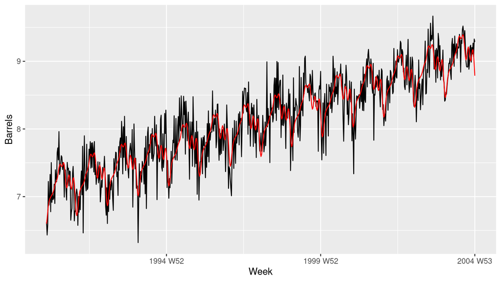

```r
best_name <- glance(gas_fits) |> slice_min(AICc, n = 1) |> pull(.model)
best_fit <- gas_fits |> select(all_of(best_name))
augment(best_fit) |>
  ggplot(aes(Week)) +
  geom_line(aes(y = Barrels)) +
  geom_line(aes(y = .fitted), colour = "red")
```

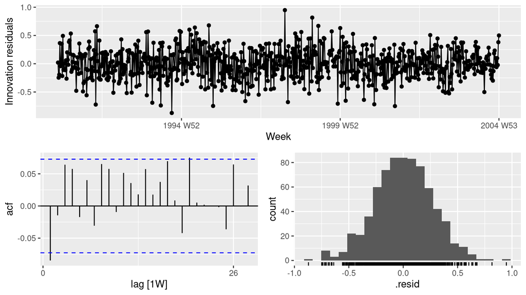

```r
gg_tsresiduals(best_fit)
```

```r
augment(best_fit) |> features(.innov, ljung_box, lag = 52)
```

```
## # A tibble: 1 × 3
##   .model lb_stat lb_pvalue
##   <chr>    <dbl>     <dbl>
## 1 K7        56.9     0.299
```

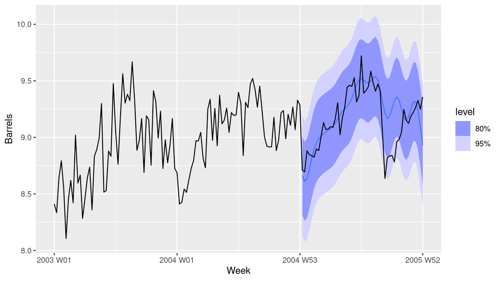

```r
fc_gas <- forecast(best_fit, h = 52)
autoplot(fc_gas, us_gasoline |> filter(year(Week) %in% 2003:2005))
```

```r
accuracy(fc_gas, gas_test)
```

```
## # A tibble: 1 × 10
##   .model .type      ME  RMSE   MAE    MPE  MAPE  MASE RMSSE  ACF1
##   <chr>  <chr>   <dbl> <dbl> <dbl>  <dbl> <dbl> <dbl> <dbl> <dbl>
## 1 K7     Test  -0.0476 0.199 0.143 -0.549  1.57   NaN   NaN 0.670
```

Гармоники повторяют внутригодовую волну, тренд — общий рост. Если Ljung–Box отвергает остатки, в ошибках остаётся короткая память, и прогноз на 2005 год по форме похож на прошлые годы, но локальные скачки поставок не ловит.

## 6. Население Афганистана

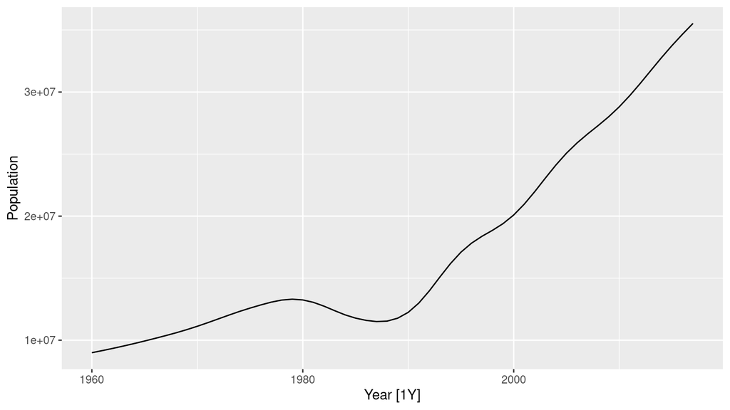

```r
afg <- global_economy |>
  filter(Country == "Afghanistan") |>
  select(Population)
autoplot(afg, Population)
```

```r
fit_afg <- afg |>
  model(
    linear = TSLM(Population ~ trend()),
    piece = TSLM(Population ~ trend(knots = c(1980, 1989)))
  )
glance(fit_afg)
```

```
## # A tibble: 2 × 15
##   .model r_squared adj_r_squared  sigma2 statistic  p_value    df log_lik   AIC
##   <chr>      <dbl>         <dbl>   <dbl>     <dbl>    <dbl> <int>   <dbl> <dbl>
## 1 linear     0.838         0.835 1.02e13      290. 8.37e-24     2   -950. 1741.
## 2 piece      0.999         0.999 9.05e10    12929. 4.34e-77     4   -812. 1469.
## # ℹ 6 more variables: AICc <dbl>, BIC <dbl>, CV <dbl>, deviance <dbl>,
## #   df.residual <int>, rank <int>
```

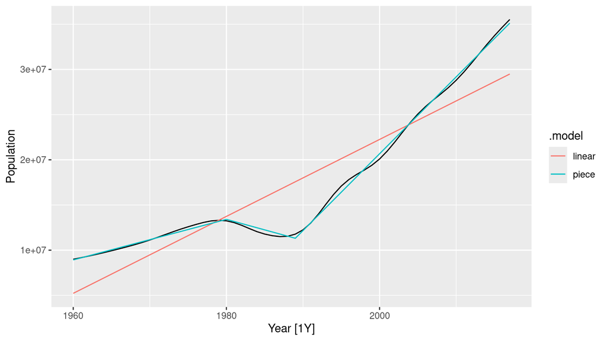

```r
autoplot(afg, Population) +
  geom_line(aes(y = .fitted, colour = .model),
            data = augment(fit_afg))
```

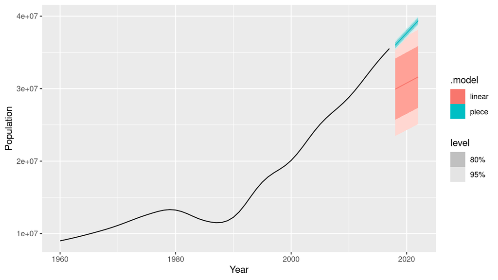

```r
forecast(fit_afg, h = 5) |>
  autoplot(afg)
```

Кусочный тренд повторяет три режима и на пять лет вперёд продолжает последний наклон. Прямая тянет средний наклон за всю историю и завышает или занижает конец ряда.

### Формулы для $y_t = \beta_0 + \beta_1 t$

Пусть $t = 1,\ldots,T$, $\sum t = T(T+1)/2$, $\sum t^2 = T(T+1)(2T+1)/6$.

$$X'X = \begin{pmatrix} T & \sum t \\ \sum t & \sum t^2 \end{pmatrix}
= \frac{1}{6}\begin{pmatrix} 6T & 3T(T+1) \\ 3T(T+1) & T(T+1)(2T+1) \end{pmatrix}.$$

Определитель $T\sum t^2 - (\sum t)^2 = T^2(T^2-1)/12$. Обратная матрица:

$$(X'X)^{-1} = \frac{2}{T(T^2-1)}
\begin{pmatrix} (T+1)(2T+1) & -3(T+1) \\ -3(T+1) & 6 \end{pmatrix}.$$

$\hat\beta = (X'X)^{-1} X'y$, поэтому

$$\hat\beta_0 = \frac{2}{T(T-1)}\left[(2T+1)\sum y_t - 3\sum t y_t\right],
\quad
\hat\beta_1 = \frac{6}{T(T^2-1)}\left[2\sum t y_t - (T+1)\sum y_t\right].$$

Прогноз в момент $T+h$: $\hat y = \hat\beta_0 + \hat\beta_1(T+h)$, дисперсия $\sigma^2\left[1 + x^*(X'X)^{-1}(x^*)'\right]$ при $x^* = (1,\ T+h)$. Подстановка даёт

$$\mathrm{Var}(\hat y_{T+h}) = \sigma^2\left[1 + \frac{2}{T(T-1)}\left(1 - 4T - 6h + 6\frac{(T+h)^2}{T+1}\right)\right].$$

Проверка на ряде Афганистана: закрытая форма и `lm` совпадают.

```r
y <- afg$Population
Tlen <- length(y)
tt <- seq_len(Tlen)
sy <- sum(y)
sty <- sum(tt * y)
b1 <- 6 / (Tlen * (Tlen^2 - 1)) * (2 * sty - (Tlen + 1) * sy)
b0 <- 2 / (Tlen * (Tlen - 1)) * ((2 * Tlen + 1) * sy - 3 * sty)
c(b0, b1)
```

```
## [1] 4798904.0  425774.1
```

```r
coef(lm(y ~ tt))
```

```
## (Intercept)          tt
##   4798904.0    425774.1
```